# A function for making risk curves

### Avoid repetitions - use functions

In `SAS` we have macros, `R` lets us use functions. Here we aim to develop a function which will let us make a risk plot for a specified value of `analysis` in our `risk` data set.

The first step is to develop one of the plots, then we wrap a function around the code (as you might also do when developing macros), finally we call the function for each value of `analysis`.

#### Subsetting to one analysis

Use `filter()` to make a data set called `temp` including only results from `risk` where `analysis` takes the value `"Cholera"`. Do this by first defining a global value `thisanalysis` as `"Cholera"`, then use `thisanalysis` rather than `"Cholera"` when filtering.

**Hint**

Specify `thisanalysis`

```r
thisanalysis <- "Cholera"
```

Then apply `filter()` where you restrict to `analysis` equaling `thisanalysis`

**Solution**

```r
thisanalysis <- "Cholera"
temp <- risk |>
  filter(analysis == thisanalysis)
```

#### Plotting the risk curves

Now make a plot of risk against time with one curve for each exposure group. Follow the same procedure as you did when you made `base`. You can specify a template theme as well, e.g. `theme_classic()`.

**Hint**

You need to use the data set `temp`.

Use `geom_stepribbon()`, `geom_step()`, `scale_*_manual()`, `scale_y_continuous()` and `theme_*()` with parameter spefications as you did previously.

**Solution**

```r
ggplot(temp, aes(x = time, y = estimate, color = x, fill = x, ymin = lcl, ymax = ucl)) +
  geom_stepribbon(show.legend = FALSE,
                  alpha = .2,
                  aes(color = NULL)) +
  geom_step(linewidth = 2) +
  scale_color_manual(values = mypal) +
  scale_fill_manual(values = mypal) +
  scale_y_continuous(labels = percent_format(accuracy = 1)) +
  theme_classic(base_size = bsize)
```

**Risk of Cholera**

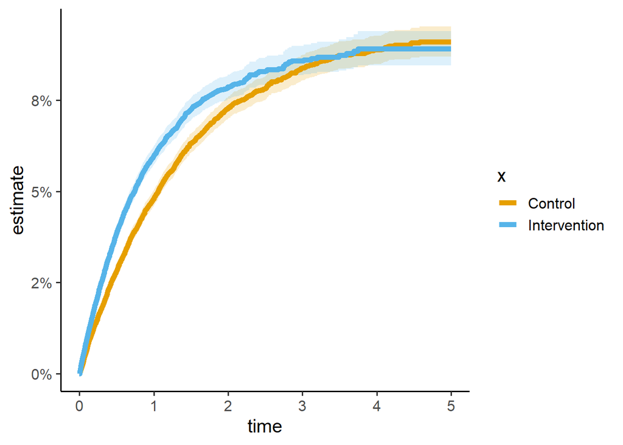

#### Controlling the legend

We want the legend within the plot in this exercise (rather than removed as in the previous). To move the legend into the plot, add a custom theme and set `legend.position` to `"inside"`. Furthermore, specify `legend.position.inside` within the theme. Let `legend.position.inside` be a numeric 2-dimensional vector with values between 0 and 1. Finally, remove the legend title by setting `legend.title` to `element_blank()` (this is also done inside your custom theme).

**Hint**

You need to specify the legend position the same way as you did when you made the plots `inner` and `outer` from `base`. Then add the extra parameter `legend.position.inside` and give it a 2-dimensional value using the function `c()`.

**Solution**

```r
ggplot(temp, aes(x = time, y = estimate, color = x, fill = x, ymin = lcl, ymax = ucl)) +
  geom_stepribbon(show.legend = FALSE,
                  alpha = .2,
                  aes(color = NULL)) +
  geom_step(linewidth = 2) +
  scale_color_manual(values = mypal) +
  scale_fill_manual(values = mypal) +
  scale_y_continuous(labels = percent_format(accuracy = 1)) +
  theme_classic(base_size = bsize) +
  theme(legend.position = "inside",
        legend.position.inside = c(.8, .2),
        legend.title = element_blank())
```

**Show plot**

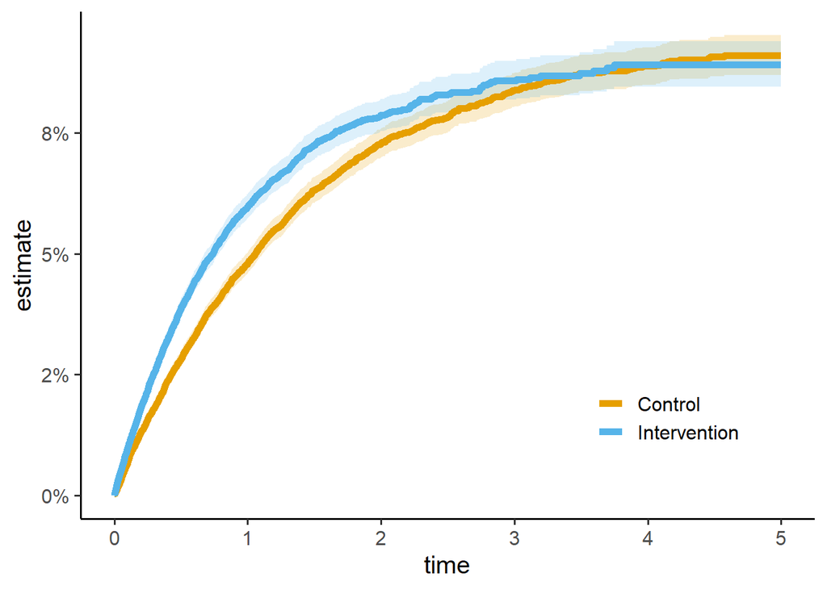

#### Axis titles

Specify that the title on the x-axis should be `"Time"`. For the y-axis we want to use the value of `thisanalysis` so it reads “Risk of [analysis]”. We will use `labs()` to set the titles. For the x-axis it is simple. For the y-axis we can use the function `paste()` which allows us to paste different strings together. In `labs()` set `y` to `paste("Risk of", thisanalysis)`.

**Solution**

```r
ggplot(temp, aes(x = time, y = estimate, color = x, fill = x, ymin = lcl, ymax = ucl)) +
  geom_stepribbon(show.legend = FALSE,
                  alpha = .2,
                  aes(color = NULL)) +
  geom_step(linewidth = 2) +
  scale_color_manual(values = mypal) +
  scale_fill_manual(values = mypal) +
  scale_y_continuous(labels = percent_format(accuracy = 1)) +
  theme_classic(base_size = bsize) +
  theme(legend.position = "inside",
        legend.position.inside = c(.8, .2),
        legend.title = element_blank()) +
  labs(x = "Time", y = paste("Risk of", thisanalysis))
```

#### Wrapping up the function

The contents of the function are essentially ready now. Wrap it up in a function which you can call `risk_fun`. The function should take the parameter `thisanalysis`.

**Hint (create a function)**

To create and name a function you can use the following code

```r
risk_fun <- function(thisanalysis) {

}
```

Put the code that the function needs to execute inside the curly brackets.

**Hint (what to put into the function)**

The function should first filter the data set then make the plot. Make sure you do not overwrite `thisanalysis` inside the function.

**Solution**

To create and name a function you can use the following code

```r
risk_fun <- function(thisanalysis) {
  temp <- risk |>
    filter(analysis == thisanalysis)

  ggplot(temp, aes(x = time,
                   y = estimate,
                   color = x,
                   fill = x,
                   ymin = lcl,
                   ymax = ucl)) +
    geom_stepribbon(show.legend = FALSE,
                    alpha = .2,
                    aes(color = NULL)) +
    geom_step(linewidth = 2) +
    scale_color_manual(values = mypal) +
    scale_fill_manual(values = mypal) +
    scale_y_continuous(labels = percent_format(accuracy = 1)) +
    theme_classic(base_size = bsize) +
    theme(
      legend.position = "inside",
      legend.position.inside = c(.8, .2),
      legend.title = element_blank()
    ) +
    labs(x = "Time", y = paste("Risk of", thisanalysis))
}
```

#### Applying the function - unifying scale on y-axes

Apply the function on the two different analyses (`risk_fun("Cholera")` and `risk_fun("Plague")`). Notice that the y-axes have different scales. Use `coord_cartesian()` inside the function to make the y-axis go to 15% (0.15).

**Hint**

In `coord_cartesian()` you need to specify `ylim` which should be given a 2-dimensional vector as input.

**Solution**

```r
risk_fun <- function(thisanalysis) {
  temp <- risk |>
    filter(analysis == thisanalysis)

  ggplot(temp, aes(x = time,
                   y = estimate,
                   color = x,
                   fill = x,
                   ymin = lcl,
                   ymax = ucl)) +
    geom_stepribbon(show.legend = FALSE,
                    alpha = .2,
                    aes(color = NULL)) +
    geom_step(linewidth = 2) +
    scale_color_manual(values = mypal) +
    scale_fill_manual(values = mypal) +
    scale_y_continuous(labels = percent_format(accuracy = 1)) +
    theme_classic(base_size = bsize) +
    theme(
      legend.position = "inside",
      legend.position.inside = c(.8, .2),
      legend.title = element_blank()
    ) +
    labs(x = "Time", y = paste("Risk of", thisanalysis)) +
    coord_cartesian(ylim = c(0,.15))
}
```

The function should now be ready for use.

**Applying the function on `"Cholera"`**

```r
risk_fun("Cholera")
```

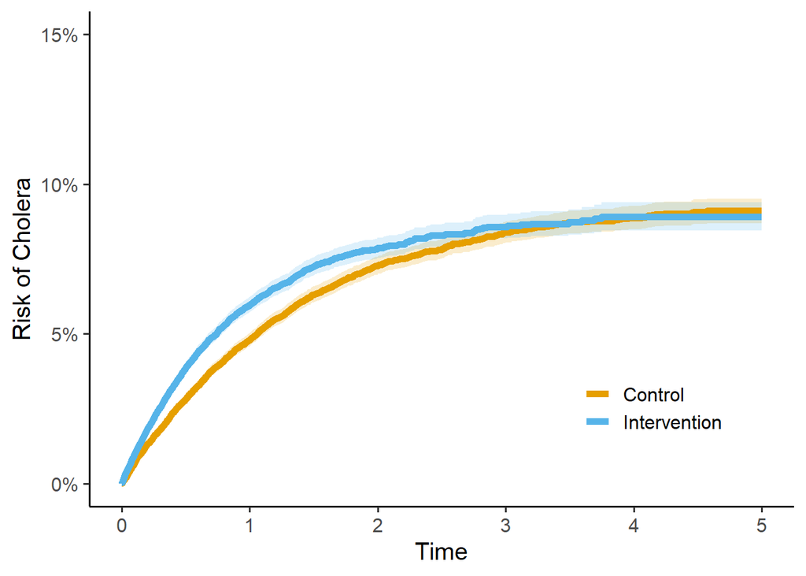